# Course Project Practical Machine Learning

Ioana Dragomirescu

March 19, 2017

1. What you should submit: The goal of your project is to predict the manner in which the participants at the study: Weigth Lifting Exercise (http://groupware.les.inf.puc-rio.br/har) did the exercise. This is the “classe” variable in the training set. You may use any of the other variables to predict with. You should create a report describing how you built your model, how you used cross validation, what you think the expected out of sample error is, and why you made the choices you did. You will also use your prediction model to predict 20 different test cases. The following libraries will be used: library(caret), library(ggplot2), library(rpart),library(rpart.plot),library(RColorBrewer),library(rattle) library(RCurl),library(randomForest). For reproducibility purposes we set seed to 3433.

```r
library(knitr)
library(caret)
```

```r
library(rpart)
library(rpart.plot)
library(rattle)
library(randomForest)
set.seed(3433)
```

The training data for this project are available here: https://d396qusza40orc.cloudfront.net/predmachlearn/pml-training.csv The test data are available here: https://d396qusza40orc.cloudfront.net/predmachlearn/pml-testing.csv The data for this project come from this source: http://groupware.les.inf.puc-rio.br/har. The database description: “Six young health participants were asked to perform one set of 10 repetitions of the Unilateral Dumbbell Biceps Curl in five different fashions: exactly according to the specification (Class A), throwing the elbows to the front (Class B), lifting the dumbbell only halfway (Class C), lowering the dumbbell only halfway (Class D) and throwing the hips to the front (Class E). Class A corresponds to the specified execution of the exercise, while the other 4 classes correspond to common mistakes. Participants were supervised by an experienced weight lifter to make sure the execution complied to the manner they were supposed to simulate. The exercises were performed by six male participants aged between 20-28 years, with little weight lifting experience. We made sure that all participants could easily simulate the mistakes in a safe and controlled manner by using a relatively light dumbbell (1.25kg).”

```r
#Defining the URL of the training and testing Data
urlTraining <- "https://d396qusza40orc.cloudfront.net/predmachlearn/pml-training.csv"
urlTesting <- "https://d396qusza40orc.cloudfront.net/predmachlearn/pml-testing.csv"

# Download training data file

fileTraining <- "pml-training.csv"
download.file(url=urlTraining, destfile=fileTraining, method="curl")

#Download test file

fileTesting <- "pml-testing.csv"
download.file(url=urlTesting, destfile=fileTesting, method="curl")

# Import the data

training <- read.csv(fileTraining, na.strings=c("NA","#DIV/0!",""), header=TRUE)

testing <- read.csv(fileTesting, na.strings=c("NA","#DIV/0!",""), header=TRUE)
```

3. Partitioning the data into training and testing data: Data are divided into training data (60%) and testing data (40%).

```r
#Partitioning the data into training and testing data

inTrain <- createDataPartition(y=training$classe, p=0.6, list=FALSE)
myTraining <- training[inTrain, ];
myTesting <- training[-inTrain, ]
dim(myTraining); dim(myTesting)
```

```
## [1] 11776   160
```

```
## [1] 7846  160
```

4. Cleaning the data: raw data- technically correct data- consistent data

```r
# remove variables with Nearly Zero Variance
NearZeroV  <- nearZeroVar(myTraining)
myTraining <- myTraining[, -NearZeroV ]
myTesting  <- myTesting[, -NearZeroV ]
dim(myTraining)
```

```
## [1] 11776   129
```

```r
dim(myTesting)
```

```
## [1] 7846  129
```

```r
# remove variables that are mostly NA
NA_V  <- sapply(myTraining, function(x) mean(is.na(x))) > 0.95
myTraining <- myTraining[, NA_V==FALSE]
myTesting  <- myTesting[, NA_V==FALSE]
dim(myTraining)
```

```
## [1] 11776    59
```

```r
dim(myTesting)
```

```
## [1] 7846   59
```

```r
names(myTraining)
```

```
##  [1] "X"                    "user_name"            "raw_timestamp_part_1"
##  [4] "raw_timestamp_part_2" "cvtd_timestamp"       "num_window"
##  [7] "roll_belt"            "pitch_belt"           "yaw_belt"
## [10] "total_accel_belt"     "gyros_belt_x"         "gyros_belt_y"
## [13] "gyros_belt_z"         "accel_belt_x"         "accel_belt_y"
## [16] "accel_belt_z"         "magnet_belt_x"        "magnet_belt_y"
## [19] "magnet_belt_z"        "roll_arm"             "pitch_arm"
## [22] "yaw_arm"              "total_accel_arm"      "gyros_arm_x"
## [25] "gyros_arm_y"          "gyros_arm_z"          "accel_arm_x"
## [28] "accel_arm_y"          "accel_arm_z"          "magnet_arm_x"
## [31] "magnet_arm_y"         "magnet_arm_z"         "roll_dumbbell"
## [34] "pitch_dumbbell"       "yaw_dumbbell"         "total_accel_dumbbell"
## [37] "gyros_dumbbell_x"     "gyros_dumbbell_y"     "gyros_dumbbell_z"
## [40] "accel_dumbbell_x"     "accel_dumbbell_y"     "accel_dumbbell_z"
## [43] "magnet_dumbbell_x"    "magnet_dumbbell_y"    "magnet_dumbbell_z"
## [46] "roll_forearm"         "pitch_forearm"        "yaw_forearm"
## [49] "total_accel_forearm"  "gyros_forearm_x"      "gyros_forearm_y"
## [52] "gyros_forearm_z"      "accel_forearm_x"      "accel_forearm_y"
## [55] "accel_forearm_z"      "magnet_forearm_x"     "magnet_forearm_y"
## [58] "magnet_forearm_z"     "classe"
```

```r
# remove identification only variables (columns 1 to 5)
myTraining <- myTraining[, -(1:5)]
myTesting  <-myTesting[, -(1:5)]
dim(myTraining)
```

```
## [1] 11776    54
```

```r
dim(myTesting)
```

```
## [1] 7846   54
```

5. Prediction Model: We apply the random forest and tree decision modeling for our predictions. The trainControl functions regarding the computational nuances of the train function will considered the cross validation method and the number of k-folds is 3.

```r
# building the random forest model

Fit1_RF <- train(classe~., trControl=trainControl(method = "cv", number = 3),data = myTraining, method="rf")
Fit1_RF$finalModel
```

```
##
## Call:
##  randomForest(x = x, y = y, mtry = param$mtry)
##                Type of random forest: classification
##                      Number of trees: 500
## No. of variables tried at each split: 27
##
##         OOB estimate of  error rate: 0.26%
## Confusion matrix:
##      A    B    C    D    E  class.error
## A 3346    1    0    0    1 0.0005973716
## B    4 2273    2    0    0 0.0026327337
## C    0    7 2047    0    0 0.0034079844
## D    0    0   10 1919    1 0.0056994819
## E    0    0    0    5 2160 0.0023094688
```

```r
##building the prediction-RF
predict_RF <- predict(Fit1_RF, newdata=myTesting)
CF_RF <- confusionMatrix(predict_RF, myTesting$classe)
CF_RF
```

```
## Confusion Matrix and Statistics
##
##           Reference
## Prediction    A    B    C    D    E
##          A 2232    8    0    0    0
##          B    0 1507    5    0    0
##          C    0    2 1363    2    0
##          D    0    1    0 1284    1
##          E    0    0    0    0 1441
##
## Overall Statistics
##
##                Accuracy : 0.9976
##                  95% CI : (0.9962, 0.9985)
##     No Information Rate : 0.2845
##     P-Value [Acc > NIR] : < 2.2e-16
##
##                   Kappa : 0.9969
##  Mcnemar's Test P-Value : NA
##
## Statistics by Class:
##
##                      Class: A Class: B Class: C Class: D Class: E
## Sensitivity            1.0000   0.9928   0.9963   0.9984   0.9993
## Specificity            0.9986   0.9992   0.9994   0.9997   1.0000
## Pos Pred Value         0.9964   0.9967   0.9971   0.9984   1.0000
## Neg Pred Value         1.0000   0.9983   0.9992   0.9997   0.9998
## Prevalence             0.2845   0.1935   0.1744   0.1639   0.1838
## Detection Rate         0.2845   0.1921   0.1737   0.1637   0.1837
## Detection Prevalence   0.2855   0.1927   0.1742   0.1639   0.1837
## Balanced Accuracy      0.9993   0.9960   0.9979   0.9991   0.9997
```

```r
#building decision tree model


Fit2_DT <- train(classe ~ .,  trControl=trainControl(method = "cv", number = 3), data = myTraining, method="rpart")
Fit2_DT$finalModel
```

```
## n= 11776
##
## node), split, n, loss, yval, (yprob)
##       * denotes terminal node
##
##  1) root 11776 8428 A (0.28 0.19 0.17 0.16 0.18)
##    2) roll_belt< 130.5 10780 7438 A (0.31 0.21 0.19 0.18 0.11)
##      4) pitch_forearm< -33.95 945    6 A (0.99 0.0063 0 0 0) *
##      5) pitch_forearm>=-33.95 9835 7432 A (0.24 0.23 0.21 0.2 0.12)
##       10) num_window>=45.5 9394 6991 A (0.26 0.24 0.22 0.2 0.088)
##         20) magnet_dumbbell_y< 439.5 7994 5645 A (0.29 0.19 0.25 0.19 0.083)
##           40) roll_forearm< 122.5 5025 2916 A (0.42 0.19 0.19 0.16 0.043) *
##           41) roll_forearm>=122.5 2969 1927 C (0.081 0.19 0.35 0.23 0.15) *
##         21) magnet_dumbbell_y>=439.5 1400  618 B (0.039 0.56 0.042 0.25 0.11) *
##       11) num_window< 45.5 441   89 E (0 0 0 0.2 0.8) *
##    3) roll_belt>=130.5 996    6 E (0.006 0 0 0 0.99) *
```

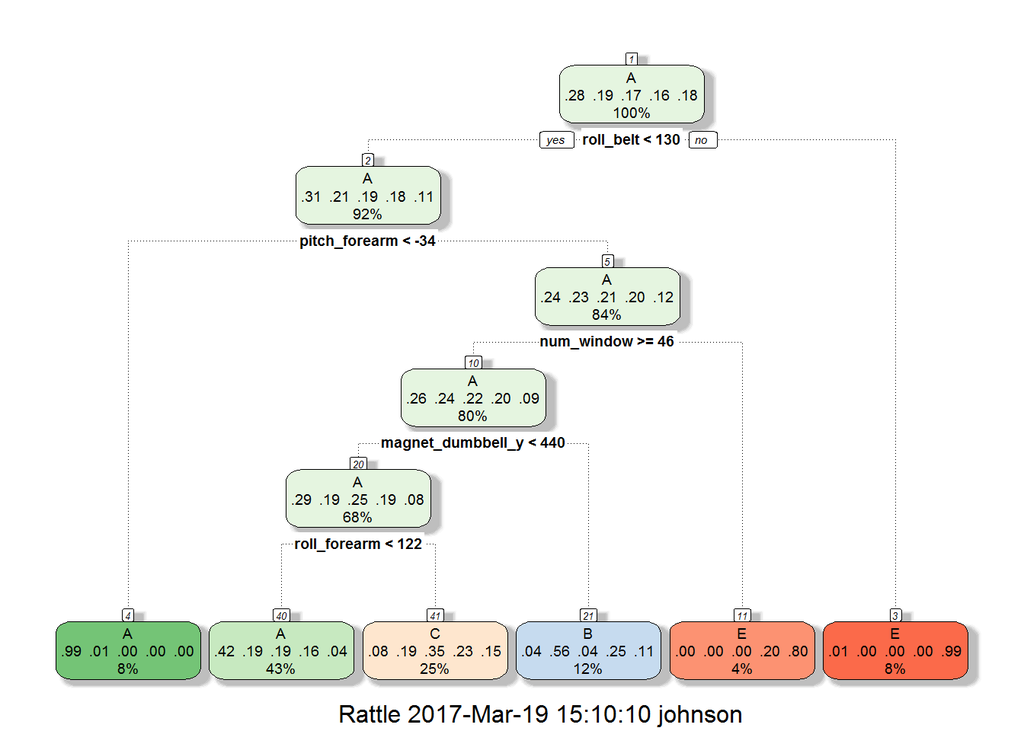

```r
fancyRpartPlot(Fit2_DT$finalModel)
```

```r
#building the prediction-Decision Tree
predict_DT<- predict(Fit2_DT, newdata=myTesting)
CF_DT <- confusionMatrix(predict_DT, myTesting$classe)
CF_DT
```

```
## Confusion Matrix and Statistics
##
##           Reference
## Prediction    A    B    C    D    E
##          A 2027  629  633  537  158
##          B   27  504   49  223  115
##          C  170  385  686  469  307
##          D    0    0    0    0    0
##          E    8    0    0   57  862
##
## Overall Statistics
##
##                Accuracy : 0.5199
##                  95% CI : (0.5088, 0.531)
##     No Information Rate : 0.2845
##     P-Value [Acc > NIR] : < 2.2e-16
##
##                   Kappa : 0.3735
##  Mcnemar's Test P-Value : < 2.2e-16
##
## Statistics by Class:
##
##                      Class: A Class: B Class: C Class: D Class: E
## Sensitivity            0.9082  0.33202  0.50146   0.0000   0.5978
## Specificity            0.6514  0.93458  0.79454   1.0000   0.9899
## Pos Pred Value         0.5088  0.54902  0.34011      NaN   0.9299
## Neg Pred Value         0.9469  0.85364  0.88300   0.8361   0.9162
## Prevalence             0.2845  0.19347  0.17436   0.1639   0.1838
## Detection Rate         0.2583  0.06424  0.08743   0.0000   0.1099
## Detection Prevalence   0.5078  0.11700  0.25707   0.0000   0.1181
## Balanced Accuracy      0.7798  0.63330  0.64800   0.5000   0.7938
```

We obtained the following accuracy values: -Random Forest : 0.9976 -Decision Tree : 0.51999

6. The Random Forest Model applied for the Test Data: Based on the accuracy results, the Random Forest model will be applied to the 20 test cases available in the test data set.

```r
predict20 <- predict(Fit1_RF, newdata=testing)
predict20
```

```
##  [1] B A B A A E D B A A B C B A E E A B B B
## Levels: A B C D E
```

7. Generate the files for submission

```r
pml_write_files = function(x){
  n = length(x)
  for(i in 1:n){
    filename = paste0("problem_id_",i,".txt")
    write.table(x[i],file=filename,quote=FALSE,row.names=FALSE,col.names=FALSE)
  }
}

pml_write_files(predict20)
```